# logboek_transcriptomics

## Introductie

zie het plan van aanpak

## Data

de data die in dit project is gebruikt is te vinden op “https://www.ncbi.nlm.nih.gov/Traces/study/?acc=PRJNA994922&o=acc_s%3Aa”. hiervan hebben wij alle data gebruikt. deze data is RNA-seq data van een groep van 5 verschillende mannelijke muizen met 7 uur slaaptekort (hc7 groep) en een groep van 5 mannelijke muizen met 5 uur slaaptekort en 2 uur rustslaap (rs2 groep). hc7 wordt in dit experiment gebruikt als controlegroep. verder hebben wij het volgende referentiegenoom van de Mus musculus gebruikt: GRCm39, te vinden op “https://www.ncbi.nlm.nih.gov/datasets/genome/GCF_000001635.27/”. dit referentiegenoom hebben wij gebruikt omdat wij een vergelijking willen doen met het gevonden experiment, waarin zij hetzelfde referentiegenoom hebben gebruikt.

de tools/packages die wij hebben gebruikt: seqtk versie 1.4-r122 fastqc versie 0.12.1 multiqc versie 1.21 STAR versie 2.7.11b dplyr versie 1.2.1 edgeR versie 4.10.5 EnhancedVolcano versie 1.30.0 Glimma versie 2.22.1 org.Mm.eg.db versie 3.23.0 clusterProfiler versie 4.20.0

## 10/21/2026

### doel van de dag

het doel van vandaag is om een artikel te vinden wat geschikt is voor transcriptomics onderzoek. daarnaast willen we de sample data van het gekozen artikel vandaag ook nog downloaden, of in ieder geval de download aan zetten.

### motivatie van aanpak

ons vorige experiment was prima te gebruiken voor genomics, maar wij hebben daar niet genoeg groepen en/of samples om dat experiment ook te gebruiken voor transcriptomics. daarom moeten wij een nieuw experiment kiezen en deze dus ook vanaf het begin af aan weer uitvoeren.

### uitgevoerde werkzaamheden

er is vandaag door mij en oscar gekeken op “https://www.ncbi.nlm.nih.gov/geo/browse/?view=series&display=20&page=4000&type=3&zsort=samples”. hier kijken wij naar een experiment met op zijn minst 6 samples en op zijn minst 2 groepen. verdere criteria zijn dat het gedaan moet zijn met high throughput sequencing. na een tijdje zoeken zijn wij op het volgende artikel gekomen: “https://www.ncbi.nlm.nih.gov/geo/query/acc.cgi?acc=GSE237419”. deze heeft een totaal van 10 samples verdeeld over 2 groepen, dus in essentie voldoet hij aan de eisen van een onderzoek voor transcriptomics. wel een tekortkoming van dit onderzoek is dat het onderzoek 3 groepen lijkt te gebruiken, terwijl zij de data van maar 2 van deze groepen vrijgeven. zij hebben namelijk data van een third party source gebruikt, zoals vermeld op “https://www.ncbi.nlm.nih.gov/geo/query/acc.cgi?acc=GSE237419”. toch kiezen wij er voor om dit experiment uit te voeren op in ieder geval de 2 zelf geteste groepen van de auteurs. eerst moeten wij daarvoor de data installeren. dit doen wij door middel van een accession list die wij downloaden van NCBI op “https://www.ncbi.nlm.nih.gov/Traces/study/?acc=PRJNA994922&o=acc_s%3Aa”.

om de data van de accession list te downloaden moeten wij het volgende commando runnen:

```bash
prefetch $(</students/2026-2027/Thema05/gr3_transcriptomics/SRA/SRR_Acc_List.txt) --output-directory \
/students/2026-2027/Thema05/gr3_transcriptomics/SRA
```

deze duurt best lang met laden, dus de resultaten hiervan zullen de volgende keer pas noteerbaar zijn. het runnen van de code gaf voor zover wij zagen geen foutmeldingen, dus wij zijn ervan uitgegaan dat deze foutloos gaat.

### resultaten

tot op het moment kunnen wij wel zien dat het eerste bestand al succesvol gedownload is. dit zegt ons waarschijnlijk dat de rest ook lukt, maar dat volgt de volgende entry.

p.s. van de dag erna, alle bestanden zijn gedownload en de bestanden zijn van de groottes die wij verwachten.

### conclusie en vervolgstappen

onze data is successvol gedownload. dit betekend dat wij morgen bezig kunnen gaan met fasterq dump om de fastq vanuit onze data te extraheren. verder kunnen wij alvast het referentiegenoom van de muis downloaden en hier een index mee maken met/voor STAR

## 23/10/2026

### doel van de dag

vandaag moeten wij ons plan van aanpak schrijven, daarvoor uitzoeken welke tools wij moeten gebruiken (en mogelijk uitvoeren) en het referentiegenoom downloaden en mogelijk een index maken van ons referentiegenoom van de mus musculus. verder moeten er nog subsets gemaakt worden van onze data.

### motivatie van aanpak

om ons experiment voor te bereiden en en beter beeld te krijgen op wat wij moeten doen met onze data, gaan wij bezig met deze dingen.

### uitgevoerde werkzaamheden

eerst heb ik vandaag het referentiegenoom GRCm39 van de mus musculus gedownload (te vinden op https://www.ncbi.nlm.nih.gov/datasets/genome/GCF_000001635.27/). hier heb ik de genome sequences (fasta), annotation features (gff en gtf) en transcripts (fasta) gedownload. daarna heb ik deze referentiegenomen in een map gezet (/students/2026-2027/Thema05/gr3_transcriptomics/Reference_sequences).

verder heb ik vandaag subsets gemaakt van onze dataset. ik heb dat gedaan door het volgende commando te runnen. met de manier waarop wij ons commando runnen, is de -s (de seed) van de subsets 676967 en is de grootte van onze subsets 100000 reads. het maken van de loop is met behulp van Marcel gedaan. verdere informatie van seqtk is vanuit het genomics logboek gehaald.

```bash
# deze loop zorgt er voor dat voor elk bestand in de folder hieronder een subset gemaakt wordt en naar de subsetfolder wordt geschreven. verder print de lijn echo het bestand waar hij op dit moment is in de terminal.

cd /students/2026-2027/Thema05/gr3_transcriptomics/fastq

for file in *.fastq; do
  base="${file%.fastq}"
  echo $base
  seqtk sample -s 676967 "${base}.fastq" 100000 > ../subset/"${base}_subset.fastq"
done
```

dit heeft voor al onze bestanden successvol een subset gemaakt. na even te kijken naar onze subsets is het duidelijk dat de maximale lengte van onze reads 100 baseparen is. dit is relevant voor de volgende stap, namelijk het maken van een indexgenoom met STAR. voor het maken van deze index heb ik het volgende commando gerund:

```bash
cd /students/2026-2027/Thema05/gr3_transcriptomics/Reference_sequences/ncbi_dataset/ncbi_dataset/data/GCF_000001635.27

STAR --runMode genomeGenerate --genomeDir /students/2026-2027/Thema05/gr3_transcriptomics/Reference_sequences/star_reference --genomeFastaFiles GCF_000001635.27_GRCm39_genomic.fna --sjdbGTFfile genomic.gtf --sjdbOverhang 99
```

ik heb de data van de subset map in een /data map gezet, zodat al onze tool runs van de subset geordent in de subsetmap geplaatst kunnen worden. daarnaast heb ik nog een /fastqc map gemaakt zodat we uiteindelijk fastqc kunnen runnen en de kwaliteit van onze subsets kunnen bekijken. dit probeer ik met de volgende code:

```bash
# deze loop zorgt er voor dat alle bestanden van onze subset een fastqc run krijgen.
cd /students/2026-2027/Thema05/gr3_transcriptomics/subset/data

for file in *.fastq; do
  base="${file%.fastq}"
  echo $base
  fastqc "${base}.fastq" --outdir /students/2026-2027/Thema05/gr3_transcriptomics/subset/fastqc
done

# noot voor later: fastqc geeft zelf al aan hoe ver het per bestand is, dus daar hoeft in principe geen echo $base voor gerund te worden.
```

dit heeft geen verdere problemen opgeleverd en de output van de fastqc is zoals verwacht. van alle subset bestanden is er een fastqc output. ik ga daar op dit moment nog geen analyse op doen, maar ik ben van plan om daar multiqc voor te gebruiken. van het vorige project (genomics) heb ik nog een multiqc geinstalleerd staan, dus die versie gebruik ik weer om multiqc te runnen. dit staat in de map /students/2026-2027/Thema05/Groep3/subset/quality_control. dit is een virtual environment en moet dus eerst geactiveerd worden om multiqc mee te kunnen runnen. dat heb ik op de volgende manier gedaan:

```bash
cd /students/2026-2027/Thema05/Groep3/subset/quality_control/venv

# om de virtual environment met multiqc te activeren run ik het volgende
source bin/activate
```

daarna heb ik de daadwerkelijke code voor multiqc gerund:

```bash
cd /students/2026-2027/Thema05/gr3_transcriptomics/subset/fastqc

multiqc --outdir /students/2026-2027/Thema05/gr3_transcriptomics/subset/multiqc .
```

het multiqc bestand wat hieruit kwam heb ik even snel bekeken. zonder te diep op de daadwerkelijke plotjes in te gaan heb ik gezien dat multiqc wel voor alle dingen een plot heeft gemaakt van alle bestanden. dit was dus een succes.

### resultaten

de resultaten van vandaag zijn een subset van al onze data, te vinden in de map /students/2026-2027/Thema05/gr3_transcriptomics/subset. verder heb ik het star commando gerund om een index te maken van het genoom, voor de mapping. deze tool is op het moment van schrijven nog niet klaar, dus de resultaten daarvan zullen de volgende keer vermeld worden. verder heb ik van alle bestanden van de subset een fastqc output. deze zijn te vinden in de folder /students/2026-2027/Thema05/gr3_transcriptomics/subset/fastqc. verder heb ik van de fastqc runs ook nog een multiqc gemaakt. deze is te vinden in de folder /students/2026-2027/Thema05/gr3_transcriptomics/subset/multiqc.

p.s. het maken van de star index is waarschijnlijk goed gegaan, aangezien ik een bestand heb van 2.7 gigabyte in de map waar ik mijn star index output wilde.

### conclusie en vervolgstappen

de conclusie van vandaag is dat de voorbereiding van ons project zo goed als klaar is. er moet nog een plan van aanpak voor ons daadwerkelijke project geschreven worden, zodat wij ook een leidende draad hebben in het transcriptomics project.

## 26/10/2026

### doel van de dag

vandaag is het doel om te werken aan het plan van aanpak.

### motivatie van aanpak

het plan van aanpak moet nog afgeschreven worden, zodat wij een handleiding hebben waarmee wij verder kunnen.

### uitgevoerde werkzaamheden

eerst heb ik gekeken naar het door jasmijn geschreven plan van aanpak en hierop mijn commentaar geleverd. het verdere schrijven van een nieuw plan van aanpak zou verder door Jasmijn gedaan worden. verder wilden we al een begin gaan maken met de read mapping dmv star. daarvoor heb ik met behulp van marcel het volgende script geschreven:

```bash
# goede directory klaarzetten voor het volgende commando
cd /students/2026-2027/Thema05/gr3_transcriptomics/subset/data

# dit commando zorgt ervoor dat de namen van de accession list die wij eerder hebben gedownload worden gepakt, waarna deze worden gebruikt voor STAR, eindigend op _1_subset.fastq en/of _2_fastq. dit zorgt er voor dat STAR zowel de forward als backward reads van onze data ziet en runt.
cat /students/2026-2027/Thema05/gr3_transcriptomics/SRA/SRR_Acc_List.txt | parallel STAR --runThreadN 4 \
--genomeDir /students/2026-2027/Thema05/gr3_transcriptomics/Reference_sequences/star_reference \
--readFilesIn {}_1_subset.fastq {}_2_subset.fastq \
--outFileNamePrefix /students/2026-2027/Thema05/gr3_transcriptomics/subset/star_alex/{}_star_ \
--outSAMtype BAM SortedByCoordinate \
--outSAMattributes Standard \
--quantMode GeneCounts
```

de tweaks van STAR in deze run doen het volgende: –genomeDir: hier geef je aan in welke directory het (geindexeerde) genoom staat –readFilesIn: dit geeft aan welk bestand je wilt gebruiken om te mappen –outFileNamePrefix: STAR maakt meerdere bestanden. hiermee geef je aan waar die namen mee beginnen. –outSAMtype: dit is het type outputbestand –outSAMattributes: hier kan je voor sam/bam bestanden verschillende tags toevoegen (zie https://samtools.github.io/hts-specs/SAMtags.pdf voor meer informatie) –quantMode: dit zorgt ervoor dat STAR een extra outputbestand maakt met daarin de gene counts (hoeveel reads per gen). bij nader inzien gaan wij deze niet gebruiken, dus zou dit in de toekomst weggelaten kunnen worden. – runThreadN: limiteerd het aantal threads waar de tool op runt

tijdens het schrijven van dit commando had Oscar ook al wat gemaakt, dus in plaats van de map /students/2026-2027/Thema05/gr3_transcriptomics/subset/star heb ik mijn run gedaan in /students/2026-2027/Thema05/gr3_transcriptomics/subset/star_alex. de output van deze runs zou niet moeten verschillen, aangezien het met dezelfde data en versies is gedaan. het vershil in onze code is dat die van Oscar een voor een runt en die van mij parallel runt. voor verder inzicht over de code van Oscar kan je in zijn logboek kijken. na het runnen van star op onze subset hebben wij ook een run aangezet voor onze daadwerkelijke data. dit is bewust met zijn geschreven script gedaan, omdat die dus niet parallel runt en wat vriendelijker is voor de assemblix server.

### resultaten

onze read mapping is successvol voor onze subset en waarschijnlijk ook successvol op onze volle dataset gerund.

### conclusie en vervolgstappen

voor het plan van aanpak moet er nog een finale versie geschreven worden en de tools moeten nog gerund worden.

## 28/10/2026

### doel van de dag

een finale versie van het plan van aanpak schrijven

### motivatie van aanpak

Jasmijn heeft een plan van aanpak geschreven, Oscar en ik gaan daar naar kijken om de fouten eruit te halen en verbeteringen proberen te maken

### uitgevoerde werkzaamheden

vandaag hebben Oscar en ik aanpassingen gemaakt in het geschreven plan van aanpak. de versie met onze aanpassingen hebben wij doorgestuurd naar Jasmijn voor een laatste check.

### resultaten

een compleet plan van aanpak

### conclusie en vervolgstappen

de volgende stap in ons project is het uitzoeken van tximeta. (en verdere vervolgstappen)

## 30/10/2026

### doel van de dag

vandaag gaan we tximeta uitzoeken en proberen te runnen met onze data

### motivatie van aanpak

dit is de volgende stap voor onze transcriptomics pijplijn

### uitgevoerde werkzaamheden

bij nader inzien van Marcel moeten wij een begin gaan maken met de exploratieve analyses in R. hierdoor hebben wij in plaats van tximeta gekozen voor featurecounts als manier om onze counts per gen te krijgen. daardoor hebben wij het volgende commando gerunt:

```bash
cd /students/2026-2027/Thema05/gr3_transcriptomics/subset/star

featureCounts -t exon \
-g gene_id \
-a /students/2026-2027/Thema05/gr3_transcriptomics/Reference_sequences/ncbi_dataset/ncbi_dataset/data/GCF_000001635.27/genomic.gtf \
-s 2 \
-o counts.txt \
-p \
--countReadPairs \
-T 32 \
*.bam
```

dit was successvol. nadatik hem hier heb gerunt, heeft Oscar hem ook nog op de hele dataset gerunt. de tweaks die wij hebben gebruikt betekenen het volgende: -t exon: de standaard, dit zorgt ervoor dat featurecounts naar de exonen kijkt in ons GTF-bestand -g gene_id: groepeerd de data op het gen-id. -a /students/2026-2027/Thema05/gr3_transcriptomics/Reference_sequences/ncbi_dataset/ncbi_dataset/data/GCF_000001635.27/genomic.gtf: de locatie van het .gtf bestand -s 2: zorgt ervoor dat de reverse reads bekeken worden door de gekozen tool. dit doen wij in verband met onze sequencing methode, te vinden in het plan van aanpak. -o counts.txt: output bestand -p: geeft aan dat onze data uit paired end reads bestaat –countReadPairs: zorgt ervoor dat forward en backward reads niet allebei opgeteld worden als dit op hetzelfde gen zit -T 32: het aantal threads waarop ons commando runt

```r
library(dplyr)
library(edgeR)
```

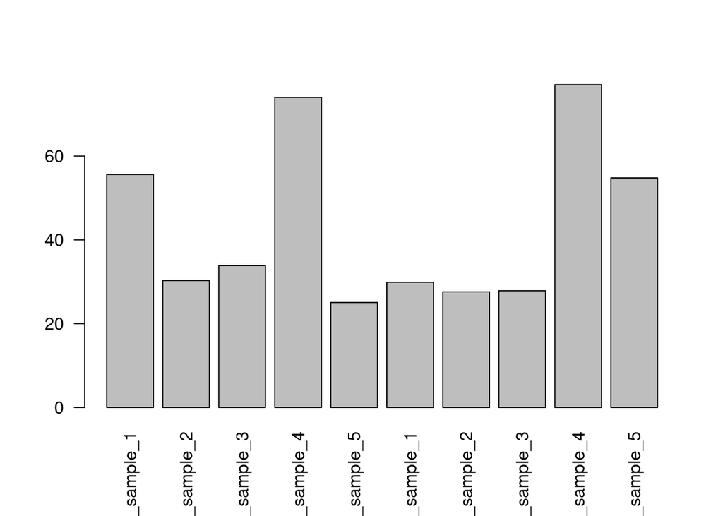

```r
count_table <- read.table("/students/2026-2027/Thema05/gr3_transcriptomics/realset/star/counts.txt", header=T, row.names = 1)

# hier vraag ik de kolomnamen van de dataframe op.
kolomnamen <- colnames(count_table)

# van de opgevragen kolommen filter ik de kolommen met onze daadwerkelijke counts eruit.
dataframe_counts <- select(count_table, c(kolomnamen[6:15]))

colnames(dataframe_counts) <- c("rs_sample_1", "rs_sample_2", "rs_sample_3", "rs_sample_4", "rs_sample_5", "control_sample_1", "control_sample_2", "control_sample_3", "control_sample_4", "control_sample_5")

# met het volgende plotje zien wij hoeveel reads er zijn gemapt per sample.
barplot(colSums(dataframe_counts)/1e6, las= 2)
```

voordat wij onze pca willen doen, moeten wij nog de data gaan normaliseren. dit doen wij op de volgende manier:

```r
# factor maken om de data te groeperen
group <- factor(c(1,1,1,1,1,2,2,2,2,2), labels = c("rs2","control"))

# het groeperen van de data
y <- DGEList(counts=dataframe_counts,group=group)

# dan normaliseren wij de data op de volgende manier
count_tpm <- tpm(y, count_table$Length)
```

dan gaan wij nu onze daadwerkelijke pca-analyse doen:

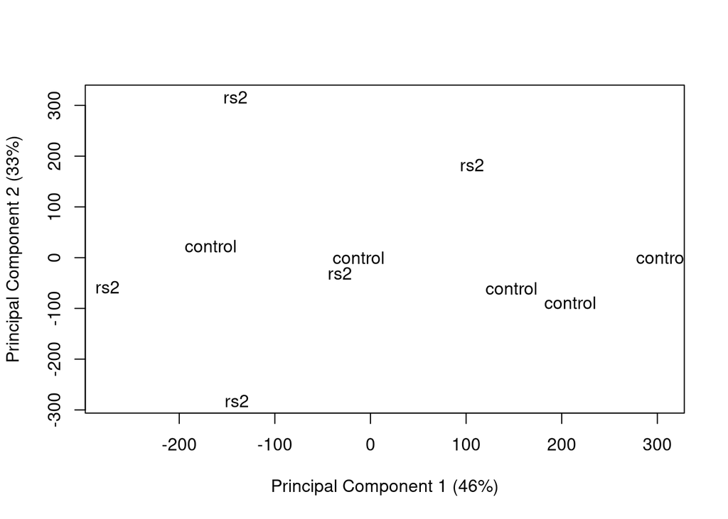

```r
# door gene.selection="common" te gebruiken met plotMDS wordt er een pca uitgevoerd
plotMDS(count_tpm, gene.selection = "common", labels = c("rs2","control"))
```

```r
?plotMDS
```

### resultaten

de resultaten van vandaag zijn readcount data, een plot van het totaal aantal reads op elke sample en de plot van de pca.

### conclusie en vervolgstappen

de volgende keer moeten we onze data nog gaan filteren en kijken naar de differentiale expressie en validatie.

## 2/11/2026

### doel van de dag

vandaag willen wij verder met onze analyse, wat betekend dat wij de DEG’s willen vastleggen.

### motivatie van aanpak

dit is de volgende stap in onze analyse. door het vast te leggen van DEG’s kunnen wij verder gaan kijken naar de effecten van deze genen.

### uitgevoerde werkzaamheden

door middel van de quick start van de user guide van edgeR (te vinden op https://bioconductor.org/packages/3.23/bioc/vignettes/edgeR/inst/doc/edgeRUsersGuide.pdf) zijn we gaan kijken wat er verder gedaan moet worden in onze analyse. na deze stappen te vergelijken met de dingen die wij vorige keer hebben gedaan, zijn wij de vorige keer vergeten om onze data te filteren.

samen hebben we code proberen te maken voor filtering van minimaal 10 reads voor een paar samples. de code staat bij Oscar in het logboek. achteraf gezien kunnen wij dit gewoon doen door middel van de functie filterByExpr van edgeR. wij hebben de volgende code uitgezocht en geschreven:

```r
# factor maken om de data te groeperen. relevel wordt gebruikt omdat onze rs2 dan uiteindelijk wordt vergeleken met de control, en niet andersom.
group <- factor(c(1,1,1,1,1,2,2,2,2,2), labels = c("rs2","control"))
group <- relevel(group, ref="control")


# het groeperen van de data
y <- DGEList(counts=dataframe_counts,group=group)

# in deze lijnen gebeurt het filteren. verdere tweaks om toe te passen zijn te vinden/gevonden op https://rdrr.io/bioc/edgeR/man/filterByExpr.html. minimale expressie staat op 10 aangezien dat volgens de volledige documentatie van edgeR (https://f1000research.com/articles/5-1438/v2) als rule of thumb gebruikt wordt.

keep <- filterByExpr(y, group=group, min.count = 10)
y <- y[keep,,keep.lib.sizes=FALSE]

# dan normaliseren wij de data op de volgende manier
# wij kiezen hier voor normlibsizes in plaats van TPM, omdat normlibsizes de normalisering over alle samples doet en niet alleen per sample.
y <- normLibSizes(y)

# https://bioconductor.org/packages/release/workflows/vignettes/RNAseq123/inst/doc/designmatrices.html
# dit maakt een model waarin beschreven worden in welke groepen de samples zitten. dit hebben wij nodig voor de volgende stappen.
design <- model.matrix(~group)

# "Conduct genewise statistical tests for a given coefficient or contrast." uitleg te vinden op https://www.rdocumentation.org/packages/edgeR/versions/3.14.0/topics/glmQLFit
fit <- glmQLFit(y,design)

# deze lijn kijkt of er een significant verschil is tussen rs2 en de controle
qlf <- glmQLFTest(fit,coef=2)

# deze lijn pakt de top DEG's, default is 10
topTags(qlf)
```

```
## Coefficient:  grouprs2
##              logFC   logCPM        F       PValue          FDR
## Htra1    0.8865938 6.922330 290.9729 3.005827e-11 2.060439e-07
## Mfsd2a   1.2620607 4.708332 278.5771 4.105747e-11 2.060439e-07
## Bace2   -1.5634154 1.938432 276.7772 4.303430e-11 2.060439e-07
## Cbln4    1.3779698 3.412144 272.9714 4.748649e-11 2.060439e-07
## Hspa5    0.8433494 7.946309 244.7831 1.032659e-10 3.584565e-07
## Sult1a1  1.5505949 3.420825 237.8720 1.265738e-10 3.661358e-07
## Galnt9   0.7646736 6.323336 197.1361 4.764679e-10 1.004967e-06
## Rassf3  -0.8720864 5.650879 196.3195 4.905464e-10 1.004967e-06
## Vgf      0.5622390 7.193098 190.5452 6.046853e-10 1.004967e-06
## Blnk     0.7275646 3.772008 188.7213 6.467961e-10 1.004967e-06
```

de output van toptags zijn de volgende dingen per gen:

logFC: de verwachte grootte van de verandering, gemeten op een log2 schaal. ook wel bekend als de log2 fold change. logCPM: de gemiddelde expressie van een gen over alle samples, gemeten op een log2 schaal. dit is een indicatie van hoe veel een gen voorkomt in expressie. F: de uitgerekende F-waarde. hogere waardes betekenen dat de kans groter is dat de genen differentieel expressed zijn. PValue: de P-waarde, gehaald uit de F-waarde. deze is nog niet veranderd voor multiple testing. FDR: de P-waarde die aangepast is voor multiple testing over alle genen heen. dit wordt gebruikt om de statistisch significante genen te bepalen.

### resultaten

de resultaten van de code is de “qlf” variabele. de eerste 10 lijnen hiervan zijn in het codeblok bij uitgevoerde werkzaamheden te zien.

### conclusie en vervolgstappen

uit deze tabel is het nog moeilijk om een conclusie te trekken. de volgende stap die we moeten zetten is het visualiseren van deze data. als we de data hebben gevisualiseerd kunnen wij betere conclusies trekken over onze data.

## 3/11/2026

### doel van de dag

het doel van vandaag is om de data van de vorige keer te plotten. dit wordt met een volcanoplot gedaan.

### motivatie van aanpak

om een daadwerkelijke uitspraak te doen over onze data moeten we deze eerst visualiseren, zodat er te zien is wat deze dingen betekenen.

### uitgevoerde werkzaamheden

ik ben bezig geweest met het uitvogelen van EnhancedVolcano, te zien in het volgende stuk code:

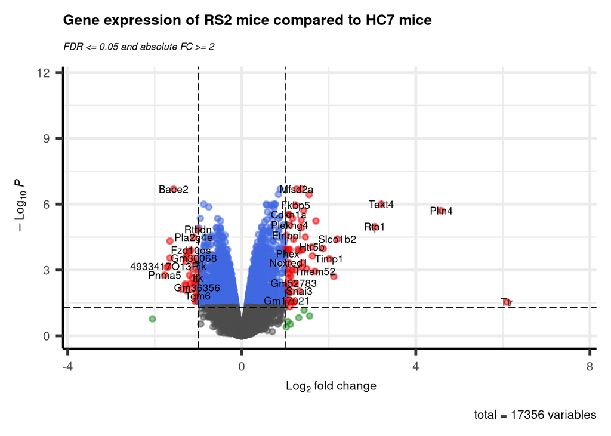

```r
library(EnhancedVolcano)
# door in toptags n=Inf aan te geven geeft de functie alle genen terug ipv de top 10, wat default is.
toptags_qlf <- as.data.frame(topTags(qlf, n=Inf))

EnhancedVolcano(toptags_qlf, x =  "logFC", y = "FDR",
                         lab=rownames(toptags_qlf),
                         title = paste("Gene expression of RS2 mice compared to HC7 mice"),
                         subtitle = bquote(italic('FDR <= 0.05 and absolute FC >= 2')),
                         # Change text and icon sizes
                         labSize = 3, pointSize = 1.5, axisLabSize=10, titleLabSize=12,
                         subtitleLabSize=8, captionLabSize=10,
                         # Disable legend
                         legendPosition = "none",
                         # Set cutoffs
                         pCutoff = 0.05, FCcutoff = 1)
```

ik heb een tijdje gestoeit met de data goed krijgen. hier kreeg ik telkens de volgende melding uit:

Error in EnhancedVolcano(toptags_qlf, x = “logFC”, y = “FCR”, lab = rownames(res), : FCR is not numeric!

mijn verwachting is dat de data van toptags niet helemaal bruikbaar is als input voor EnhancedVolcano. daarom ben ik er op gekomen om de toptags als een dataframe te zetten. wat er daadwerkelijk fout ging is een beetje suf. in de enhancedvolcano plot had ik namelijk “FCR” als y gezet inplaats van “FDR” :(.

```r
# deze lijnen gebruik ik om te filteren op logFC > 1 en FDR < 0.05
top_degs <- toptags_qlf[toptags_qlf$logFC > 1,]

top_degs <- top_degs[top_degs$FDR < 0.05,]

top_degs
```

```
##                  logFC       logCPM          F       PValue          FDR
## Mfsd2a        1.262061  4.708332497 278.577101 4.105747e-11 2.060439e-07
## Cbln4         1.377970  3.412144483 272.971406 4.748649e-11 2.060439e-07
## Sult1a1       1.550595  3.420824926 237.871979 1.265738e-10 3.661358e-07
## Tekt4         3.210442 -0.369021914 188.944580 6.948374e-10 1.004967e-06
## Fkbp5         1.239322  5.315840915 178.744801 9.450338e-10 1.093467e-06
## Smim3         1.423367  3.008651014 158.884614 2.139743e-09 1.954599e-06
## Plin4         4.590063  3.331426163 157.624922 2.265815e-09 1.966274e-06
## Cdkn1a        1.080344  4.474491181 145.649924 3.892331e-09 2.937187e-06
## Mdga1         1.094595  4.398330924 144.191679 4.170177e-09 3.015733e-06
## Rasd1         1.167910  1.660644372 132.291634 7.508836e-09 4.445659e-06
## Pglyrp1       1.371084  1.798102525 126.307660 1.027674e-08 5.404941e-06
## Gm19439       1.705415  1.722547322 123.709742 1.182831e-08 5.865488e-06
## Plekhg4       1.101865  2.329056397 114.574909 1.980255e-08 9.044552e-06
## Rtp1          3.058918 -0.418270176 111.915854 2.476216e-08 1.061036e-05
## Fndc9         1.370516  1.364249173 106.724736 3.180716e-08 1.200098e-05
## Etnppl        1.025964  3.669517285  88.427057 1.093164e-07 2.635134e-05
## Spink8        1.462470 -0.180912896  85.676238 1.351090e-07 3.168853e-05
## Slco1b2       2.196190  0.001330083  80.648905 2.007480e-07 3.871314e-05
## Itga11        1.191940  1.371951214  79.804268 2.118079e-07 3.952837e-05
## Htr5b         1.613454 -0.579988522  67.162775 6.383852e-07 8.793503e-05
## Gm46206       1.872964 -0.764527924  64.651054 8.231419e-07 1.066153e-04
## Ntmt2         1.102498  0.298106908  62.989752 9.364179e-07 1.138496e-04
## Klrg2         1.296343 -0.501535244  62.672077 9.728592e-07 1.140875e-04
## Slc4a11       1.007698  1.444841896  62.332061 9.973355e-07 1.150993e-04
## H2bc6         1.068337  0.660799613  62.192229 1.011825e-06 1.150993e-04
## Gm39080       1.397925  4.055484916  61.487354 1.084035e-06 1.190791e-04
## Gm34945       1.382041  0.502258306  60.580521 1.189045e-06 1.258358e-04
## Gm41980       1.318366  0.228335410  59.743978 1.295259e-06 1.344868e-04
## Gm31097       1.043850  0.534140747  59.296892 1.354293e-06 1.374567e-04
## Phex          1.053795  0.034233829  55.314562 2.063949e-06 1.818370e-04
## A730020M07Rik 1.625231 -0.621952455  52.307892 2.923450e-06 2.316867e-04
## Timp1         2.011908 -0.690779880  47.985352 4.905789e-06 3.089945e-04
## Gm39081       1.388865 -1.096579427  43.574871 8.527675e-06 4.654287e-04
## Noxred1       1.083006  0.489878389  43.295520 8.640291e-06 4.686278e-04
## Gpr179        1.383897 -0.647054665  38.643439 1.648700e-05 7.318371e-04
## Gm39429       1.494072  0.748768629  36.636804 2.191021e-05 8.864187e-04
## Gm41448       1.072034  0.816753644  36.085136 2.379043e-05 9.253590e-04
## Tmem82        1.237488 -0.482675103  35.414040 2.645629e-05 9.917394e-04
## Scd4          1.154123 -0.033992227  35.170512 2.737406e-05 1.010860e-03
## Tmem52        1.680787 -1.396068471  34.293766 3.226954e-05 1.145938e-03
## Gm11730       1.092887 -0.998224526  32.371371 4.302286e-05 1.393106e-03
## Hif3a         1.125599  3.609004226  29.838488 6.496513e-05 1.904619e-03
## Gm51447       2.117967  0.890855860  29.497220 6.898542e-05 1.984956e-03
## Gm16062       1.075033 -0.573292266  27.869305 9.228410e-05 2.386149e-03
## Gm52783       1.196196 -0.751150077  24.025103 1.916674e-04 3.964378e-03
## Gm31740       1.229161 -0.702398399  23.331707 2.201185e-04 4.319129e-03
## Kl            1.030385  1.782527612  22.878852 2.402158e-04 4.591613e-03
## Map3k6        1.021356  2.148825185  21.044126 3.537179e-04 5.966110e-03
## Gm42296       1.043629 -1.469154530  19.209754 5.403494e-04 7.974748e-03
## Snai3         1.324298 -1.441021867  18.354011 6.592972e-04 9.095996e-03
## Xdh           1.146967  3.214817694  17.842732 7.326824e-04 9.812065e-03
## Scn10a        1.051709 -0.942184431  17.223120 8.557057e-04 1.078978e-02
## Gm41254       1.069359 -1.382483936  16.298604 1.082024e-03 1.274922e-02
## Gm17021       1.039037 -1.101983514  12.617352 2.901392e-03 2.499085e-02
## Lrrc10b       1.176655  2.144285103  12.209989 3.251586e-03 2.689921e-02
## Opn1mw        1.124563 -1.352255486  11.977228 3.509818e-03 2.832004e-02
## Ttr           6.094922  3.704975041  11.833230 3.640694e-03 2.897198e-02
## Nts           1.203072 -1.118264451  11.638070 3.873909e-03 3.018953e-02
## Slc12a3       1.028491 -0.652184797  11.159256 4.465025e-03 3.341741e-02
## Sh3rf2        1.109099  0.613594554   9.557596 7.429102e-03 4.708557e-02
```

```r
# het aantal significante genen is gelijk aan het volgende
sum(toptags_qlf$FDR <= 0.05)
```

```
## [1] 2833
```

```r
# het aantal significant veranderde genen is in de volgende lijn gehaald
significant_degs <- toptags_qlf[toptags_qlf$FDR < 0.05,]
```

```r
BiocManager::install("Glimma")
library(Glimma)

# hierdoor krijgen we een beter inzicht van de genen. wij kunnen hiermee zien wat de expressie per individu per groep is.
glMDPlot(qlf, counts = y$counts, anno = data.frame(GeneID = rownames(y)), groups = y$samples$group)
```

### resultaten

wij hebben een volcanoplot (te zien bij uitgevoerde werkzaamheden) gemaakt. uit de data hierachter is te halen dat 7 genen een log2fold groter dan 2 (dus een verandering van 4x of meer expressie) hebben. 60 genen hebben een log2fold groter dan 1 (dus een verandering van 2x of meer expressie). er zijn 2833 genen die significant zijn veranderd (adjusted p value van 0.05 of kleiner).

### conclusie en vervolgstappen

wij hebben een heleboel significante DEG’s, wat dus betekend dat er een grote kans is dat er een verschil zit tussen de rs2 en hc7 groepen. voor de volgende keer gaan wij een enrichment analyse doen. dit gaan wij doen met behulp van de clusterProfiler library. hiermij kunnen wij de pathways van onze genen hopelijk visualiseren.

## 6/11/2026

### doel van de dag

de GO enrichment analyse en conclusies hierop te trekken.

### motivatie van aanpak

om meer inzicht te krijgen op de pathways van de genen die significant verschillen willen wij deze analyse doen.

### uitgevoerde werkzaamheden

eerst hebben we uitgezocht hoe de GO enrichment analyse met clusterProfiler moet. hier hebben we het commando “enrichGO” uit gevonden in de documentatie van clusterProfiler (te vinden op https://bioconductor.org/packages/release/bioc/html/clusterProfiler.html). een van de benodigdheden voor enrichGO is een vector met entrez-id genen. onze genen staan nog niet in entrez-format. om dit om te zetten heeft clusterProfiler het commando “bitr”. deze zet genen om van een format naar de andere. dit runnen wij op de volgende manier:

```r
# BiocManager::install("org.Mm.eg.db")
library(org.Mm.eg.db)
library(clusterProfiler)
# hier verander ik de gene symbols naar de entrez ids van onze degs. alle degs met adj.p < 0.05 zitten in significant_degs. dit gaf de waarschuwing dat 0.07% van de input genes niet gemapt zijn.
entrez_genes <- bitr(rownames(significant_degs), OrgDb = org.Mm.eg.db, fromType = "SYMBOL", toType = "ENTREZID")
# ik zet de universe klaar door al onze geteste genen mee te geven
universe <- bitr(rownames(toptags_qlf), OrgDb = org.Mm.eg.db, fromType = "SYMBOL", toType = "ENTREZID")
```

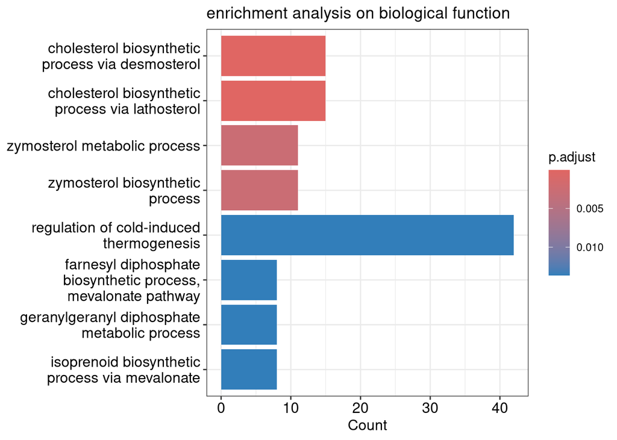

```r
# nu willen wij de daadwerkelijke enrichment analyse gaan doen dmv enrichGO:
ego <- enrichGO(
  gene = entrez_genes$ENTREZID,
  OrgDb = org.Mm.eg.db,
  keyType = "ENTREZID",
  ont = "BP",           # dit zorgt ervoor dat wij de biological processes terug krijgen van onze analyse
  universe = universe$ENTREZID
)

# hier plot ik de resultaten van de analyse.
barplot(ego, title = "enrichment analysis on biological function")
```

[figure not shown]

```r
# nu willen wij de daadwerkelijke enrichment analyse gaan doen dmv enrichGO:
ego2 <- enrichGO(
  gene = entrez_genes$ENTREZID,
  OrgDb = org.Mm.eg.db,
  keyType = "ENTREZID",
  ont = "MF",           # dit zorgt ervoor dat wij de biological processes terug krijgen van onze analyse
  universe = universe$ENTREZID
)

# hier plot ik de resultaten van de analyse.
barplot(ego2, title = "enrichment analysis on cellular components")
```

### conclusie en vervolgstappen

wij hebben wel degelijk een significant verschil in expressie tussen de rs2 groep en hc7 groep. de verschillen zitten in de pathways die in de plot te zien zijn. de pathways waarin deze DEG’s zitten zijn in grote lijnen gezegt de pathways waarmee cholesterol gemaakt wordt (cholesterol biosynthetic pathway via desmosterol/lathosterol, zymosterol metabolic/biosynthetic pathway, farnesyl diphosphate biosynthetic process, mevalonate pathway en de isoprenoid biosynthetic pathway). verder zijn de farnesyl diphosphate biosynthetic process en isoprenoid biosynthetic pathway ook nog actief bij het maken van ubiquinones, wat eiwitten zijn die deel uitmaken van de mitochondrien, wat dus zorgt voor energieproductie. in het originele experiment hebben zij ook DEG’s in cholesterolsynthese, dus dit komt daarmee overeen.

in moleculaire functie hebben wij geen significante DEG’s, terwijl zij dit in het experiment wel hadden bij de rs2 groep. hierin verschilt onze analyse met het originele experiment.